# CS 422 Section 01

## Section 2.2

### 2.2

```r
library(dplyr)
library(stats)
d<-read.csv("buddymove_holidayiq.csv", sep=",", header=T, row.names = 1)
set.seed(1122)
sample.set<-sample_n(d,size=50)
sample.set
```

|  | Sports | Religious | Nature | Theatre | Shopping | Picnic |
| --- | --- | --- | --- | --- | --- | --- |
| User 20 | 5 | 114 | 83 | 65 | 114 | 102 |
| User 4 | 2 | 68 | 77 | 95 | 76 | 61 |
| User 167 | 22 | 128 | 158 | 183 | 158 | 130 |
| User 36 | 4 | 79 | 86 | 110 | 93 | 73 |
| User 116 | 12 | 133 | 104 | 119 | 129 | 133 |
| User 115 | 14 | 94 | 163 | 99 | 94 | 153 |
| User 237 | 25 | 173 | 89 | 124 | 233 | 158 |
| User 43 | 4 | 87 | 89 | 76 | 89 | 111 |
| User 71 | 8 | 138 | 59 | 84 | 138 | 128 |
| User 1 | 2 | 77 | 79 | 69 | 68 | 95 |

[output cut: 40 more lines]

```r
scaled.data<-scale(sample.set)
scaled.data
```

```
##              Sports    Religious      Nature     Theatre    Shopping
## User 20  -0.8438782  0.206700087 -0.90689267 -1.32468472  0.03976440
## User 4   -1.2561965 -1.204012671 -1.05269535 -0.47224925 -0.87050500
## User 167  1.4925923  0.636047448  0.91564083  2.02822813  1.09376054
## User 36  -0.9813176 -0.866668316 -0.83399133 -0.04603152 -0.46327921
## User 116  0.1181979  0.789385791 -0.39658329  0.20969913  0.39908127
## User 115  0.3930768 -0.406653286  1.03714306 -0.35859119 -0.43932476
## User 237  1.9049107  2.016092537 -0.76108999  0.35177170  2.89034488
## User 43  -0.9813176 -0.621326967 -0.76108999 -1.01212505 -0.55909704
## User 71  -0.4315598  0.942724134 -1.49010339 -0.78480892  0.61467139
## User 1   -1.2561965 -0.928003653 -1.00409445 -1.21102666 -1.06214066
## User 200  1.4925923  2.476107566  0.08942564  0.06762655  1.69262199
## User 23  -0.8438782 -1.173345002 -0.05637704 -1.06895408 -1.11004957
## User 72  -0.4315598 -0.866668316  0.55113413  0.03921203 -1.03818620
## User 140 -0.1566810 -0.314650280  0.06512520 -0.10286055  0.15953669
## User 197  1.4925923  0.789385791  1.52315199  0.06762655  1.69262199
## User 170  1.2177134  1.096062477  0.45393234  0.77798944  0.63862584
## User 225  0.9428346  1.249400821 -0.51808552  0.77798944  1.33330512
## User 35  -0.9813176 -0.437320955 -0.88259222 -1.04053957 -0.67886933
## User 17  -0.8438782 -1.480021689  0.25952877 -0.24493313 -1.39750307
## User 56  -0.4315598  0.022694075 -0.27508106 -0.64273635 -0.55909704
## User 155 -0.1566810 -0.253314943  0.06512520  1.17579266  0.37512681
## User 145  0.1181979 -0.437320955  0.06512520  0.32335719  0.27930898
## User 53  -0.9813176 -0.866668316 -0.42088374 -1.23944118 -0.22373464
## User 240  0.9428346  0.206700087  0.91564083  1.88615555  1.09376054
## User 37  -0.9813176 -0.621326967 -1.17419758  0.01079752 -1.18191295
## User 157  0.1181979  0.636047448 -0.03207659 -0.21651861  0.15953669
## User 18  -0.8438782 -1.572024695  0.08942564 -0.10286055 -1.34959415
## User 98  -0.7064387  1.249400821 -1.36860115 -1.06895408  0.61467139
## User 195  1.2177134  2.169430880 -0.76108999  1.20420718  2.05193885
## User 185  0.9428346 -0.253314943  2.61667209 -0.21651861 -0.67886933
## User 14  -1.1187570 -0.437320955 -1.61160562 -1.06895408 -0.22373464
## User 73  -0.4315598 -0.713329973  0.79413860 -0.92688150 -1.15795849
## User 217  1.4925923  1.126730146  1.28014753  0.63591686  1.45307741
## User 224  0.9428346  0.636047448  1.03714306  1.74408297  0.49489910
## User 38  -0.8438782 -1.296015677  0.18662743 -0.92688150 -1.34959415
## User 199  1.4925923  0.206700087  2.25216539  0.49384428 -0.43932476
## User 76  -0.7064387  0.329370761 -1.36860115 -0.30176216  0.49489910
## User 239  1.4925923  0.513376773  1.15864530  2.73859102  0.85421596
## User 168  1.4925923  0.666715116  1.64465423 -0.07444603 -0.19978018
```

[output cut: 53 more lines]

```
## User 41  -0.99314724
## User 31  -1.02088879
## User 60  -0.90992261
## User 12  -0.77121490
## User 221  0.08877294
## User 11  -0.74347336
## User 131  1.30940084
## User 136 -0.79895644
## User 248  2.55777028
## attr(,"scaled:center")
##    Sports Religious    Nature   Theatre  Shopping    Picnic
##     11.14    107.26    120.32    111.62    112.34    120.80
## attr(,"scaled:scale")
##    Sports Religious    Nature   Theatre  Shopping    Picnic
##  7.275932 32.607630 41.151507 35.193280 41.745883 36.047021
```

#### 2.2(a)

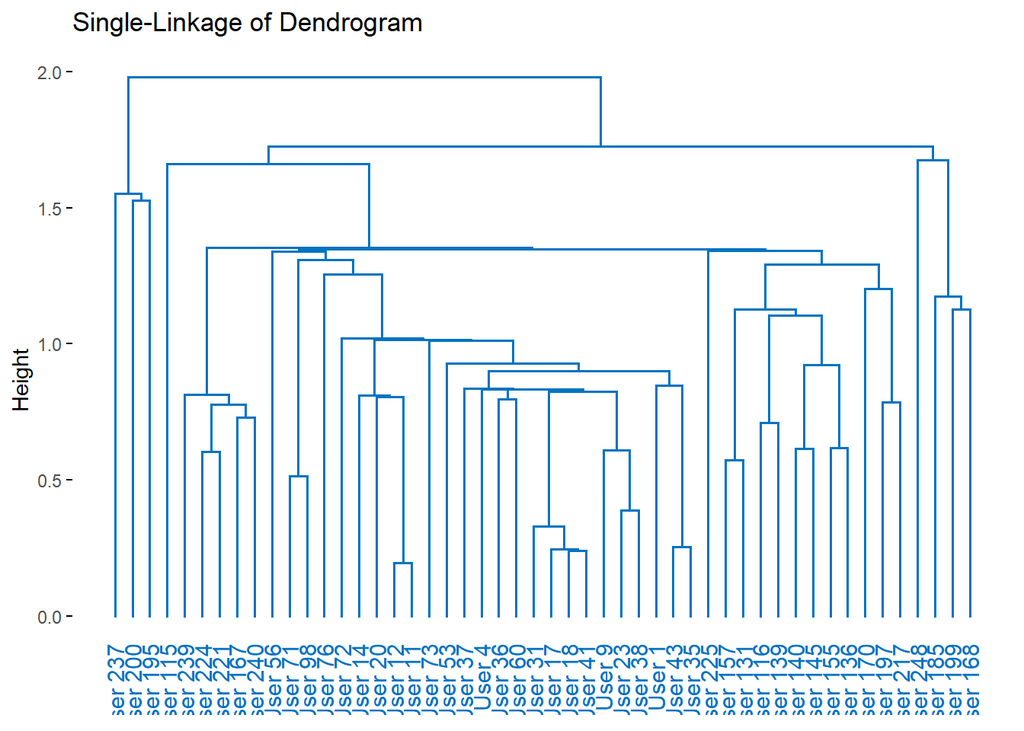

```r
library(factoextra)
library(ggplot2)

#Single Linkage
single.hclust<-eclust(scaled.data,"hclust",hc_method="single",k=1)
fviz_dend(single.hclust, show_labels=TRUE, palette="jco", as.ggplot=T, main="Single-Linkage of Dendrogram")
```

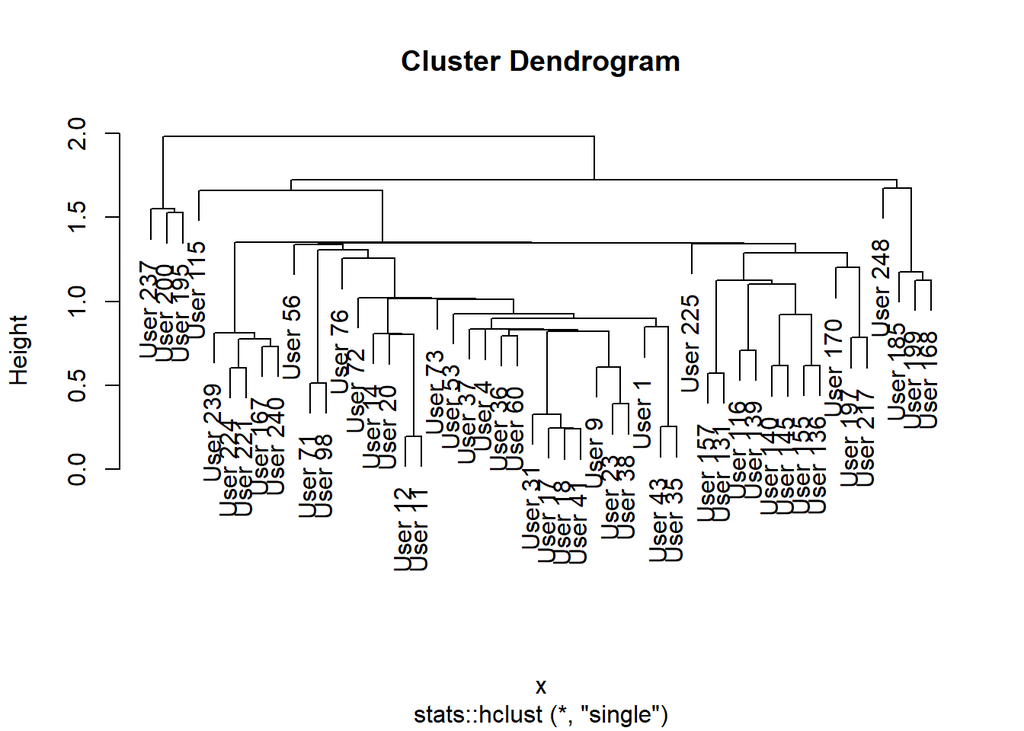

```r
plot(single.hclust)
```

```r
single.hclust$nbclust
```

```
## [1] 1
```

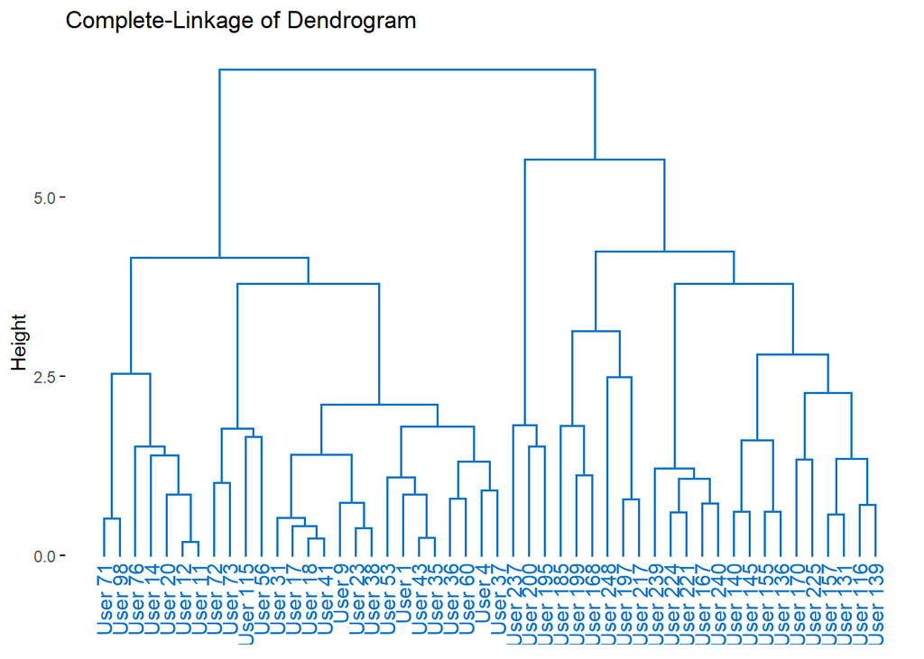

```r
#Complete Linkage
complete.hclust<-eclust(scaled.data,"hclust",hc_method = "complete",k=1)
fviz_dend(complete.hclust, show_labels=TRUE, palette="jco", as.ggplot=T, main="Complete-Linkage of Dendrogram")
```

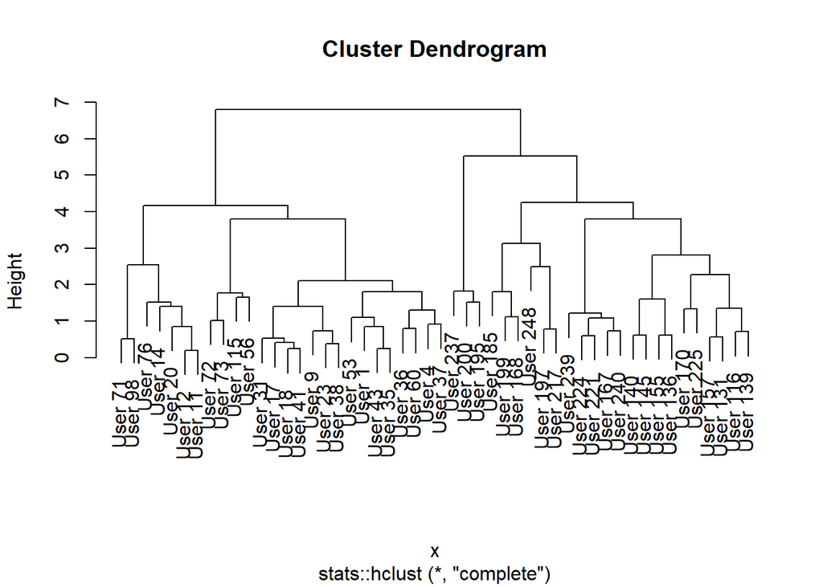

```r
plot(complete.hclust)
```

```r
complete.hclust$nbclust
```

```
## [1] 1
```

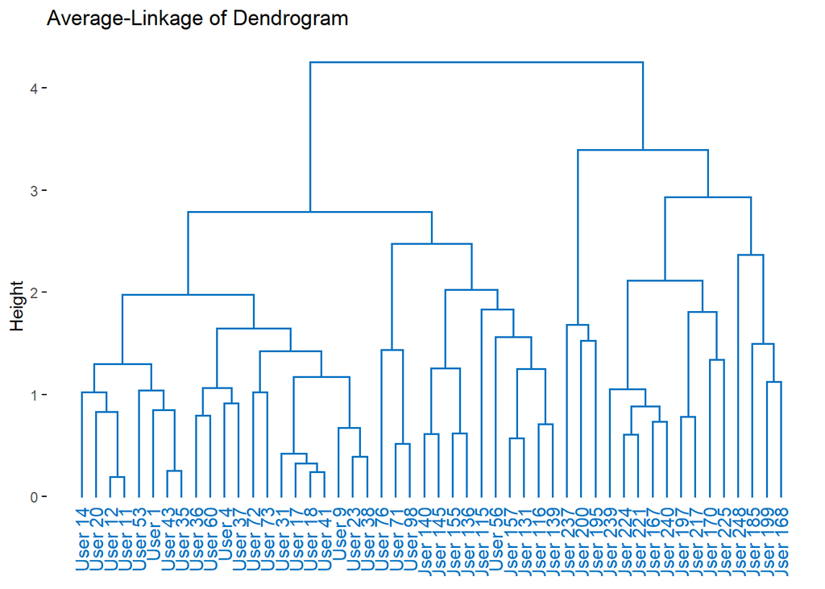

```r
#Average Linkage
avg.hclust<-eclust(scaled.data,"hclust",hc_method = "average",k=1)
fviz_dend(avg.hclust, show_labels=TRUE, palette="jco", as.ggplot=T, main="Average-Linkage of Dendrogram")
```

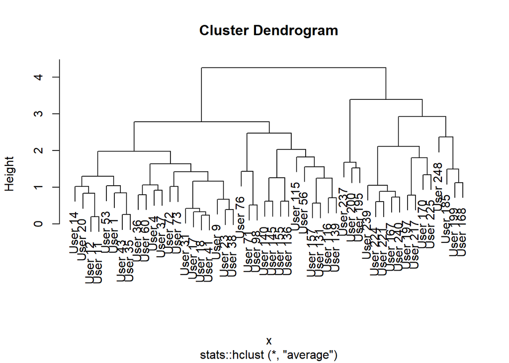

```r
plot(avg.hclust)
```

```r
avg.hclust$nbclust
```

```
## [1] 1
```

#### 2.2(b)

Single linkage singleton cluster: {User200,User195}, {User224,User221}, {User167,User240}, {User71,User98}, {User12,User11}, {User36,User60}, {User18,User41}, {User23,User38}, {User43,User35}, {User157,User131}, {User116,User139}, {User140,User145}, {User155,User136}, {User197,User217}, {User199,User168}

Complete linkage singleton cluster: {User71,User98}, {User12,User11}, {User72,User73}, {User115,User56}, {User18,User41}, {User23,User38}, {User43,User35}, {User36,User60}, {User4,User37}, {User200,User195}, {User199,User168}, {User197,User217}, {User224,User221}, {User167,User240}, {User140,User145}, {User155,User136}, {User170,User225}, {User157,User131}, {User116,User139}

Average linkage singleton cluster: {User12,User11}, {User43,User35}, {User36,User60}, {User4,User37}, {User72,User73}, {User18,User41}, {User23,User38}, {User71,User98}, {User140,User145}, {User155,User136}, {User157,User131}, {User116,User139}, {User200,User195}, {User224,User221}, {User167,User240}, {User197,User217}, {User170,User225}, {User199,User168}

#### 2.2(c)

By our definition, the Single linkage method is considered pure as it contains the least two-singleton clusters of 15.

#### 2.2(d)

```r
nclusters <- cutree(single.hclust, h=1.7)
table(nclusters)
```

```
## nclusters
##  1  2  3
## 43  3  4
```

```r
cat("The number of clusters at the height of 1.7 would be: ", max(nclusters),"\n")
```

```
## The number of clusters at the height of 1.7 would be:  3
```

#### 2.2(e)

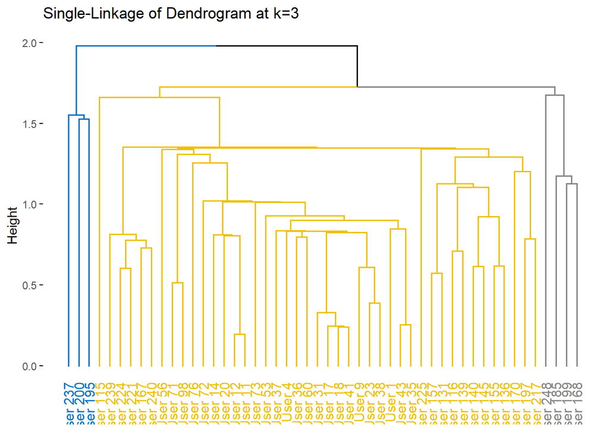

```r
#library(cluster)
#library(factoextra)
#Single Linkage Cutree

single.hclust.cut<-eclust(scaled.data,"hclust",hc_method="single",k=3)
fviz_dend(single.hclust.cut, show_labels=TRUE, palette="jco", as.ggplot=T, main="Single-Linkage of Dendrogram at k=3")
```

```
##   cluster size ave.sil.width
## 1       1   43          0.23
## 2       2    3          0.58
## 3       3    4          0.45
```

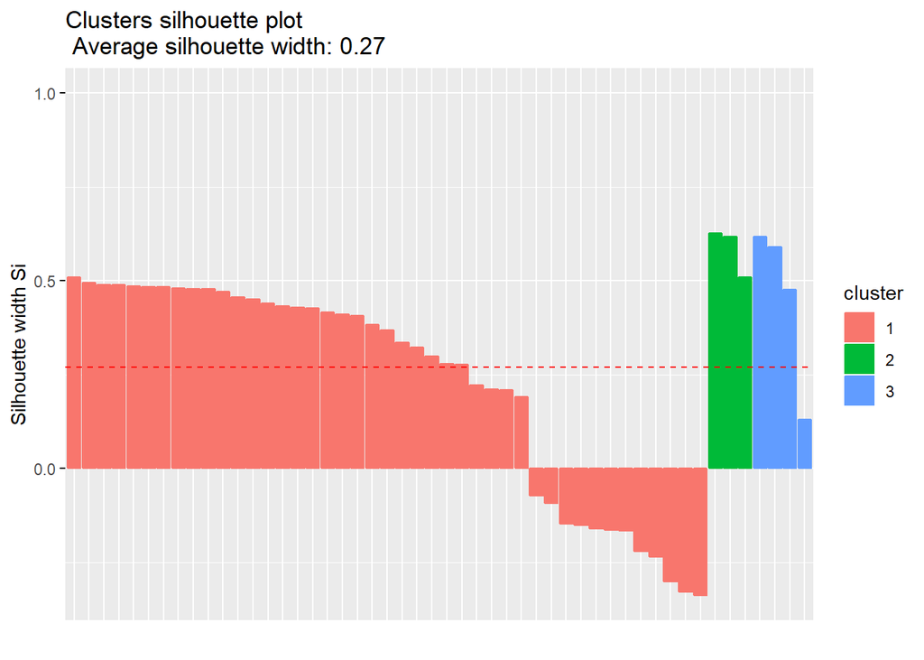

```r
fviz_silhouette(single.hclust.cut)
```

```r
single.sil <- summary(silhouette(cutree(single.hclust.cut, 3), dist(scaled.data)))
cat("The silhouette index for single linkage cluster at k=3 is: ",single.sil$avg.width,"\n")
```

```
## The silhouette index for single linkage cluster at k=3 is:  0.2703044
```

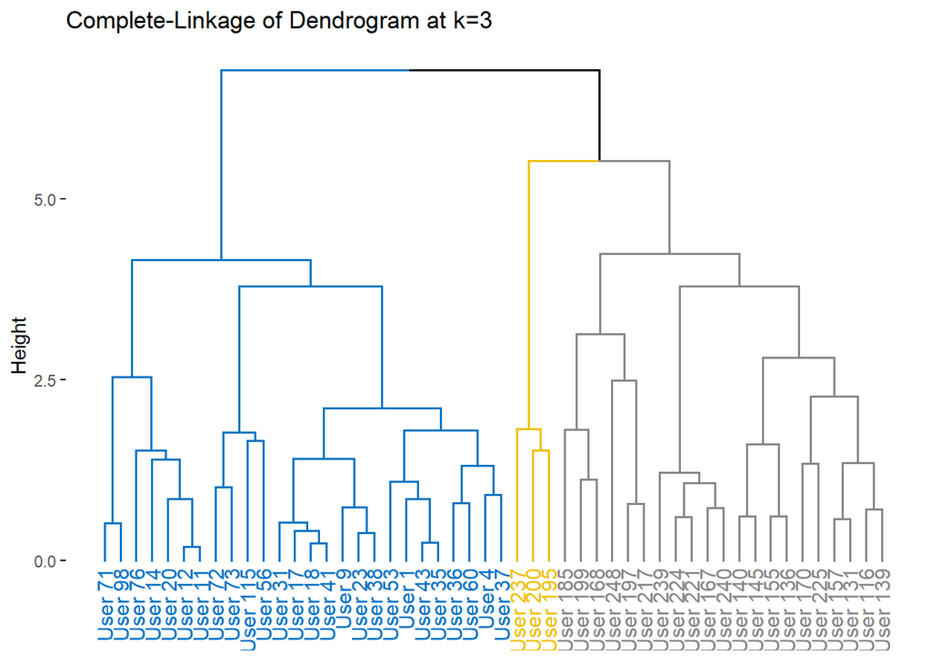

```r
#Complete Linkage
complete.hclust.cut<-eclust(scaled.data,"hclust",hc_method = "complete",k=3)
fviz_dend(complete.hclust.cut, show_labels=TRUE, palette="jco", as.ggplot=T, main="Complete-Linkage of Dendrogram at k=3")
```

```
##   cluster size ave.sil.width
## 1       1   26          0.46
## 2       2   21          0.19
## 3       3    3          0.54
```

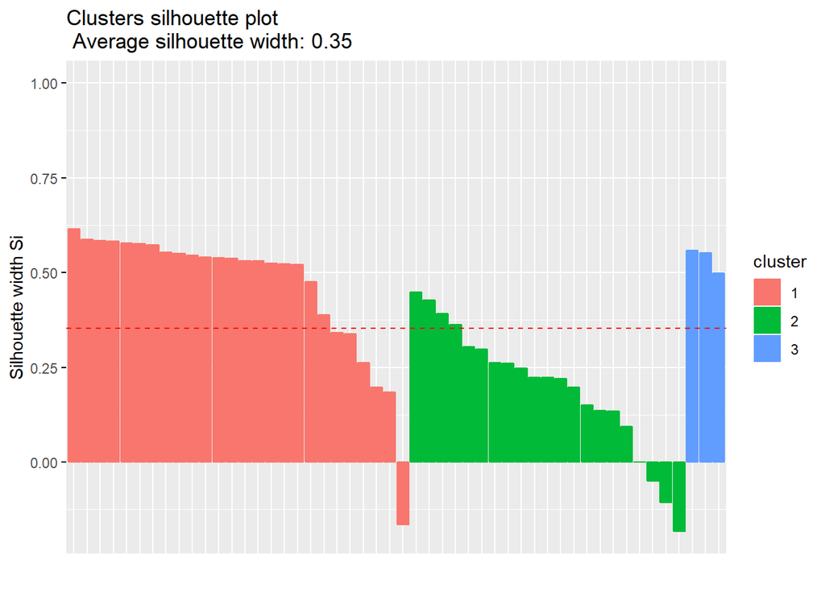

```r
fviz_silhouette(complete.hclust.cut)
```

```r
complete.sil <- summary(silhouette(cutree(complete.hclust.cut, k = 3), dist(scaled.data)))
cat("The silhouette index for complete linkage cluster at k=3 is: ",complete.sil$avg.width,"\n")
```

```
## The silhouette index for complete linkage cluster at k=3 is:  0.3533173
```

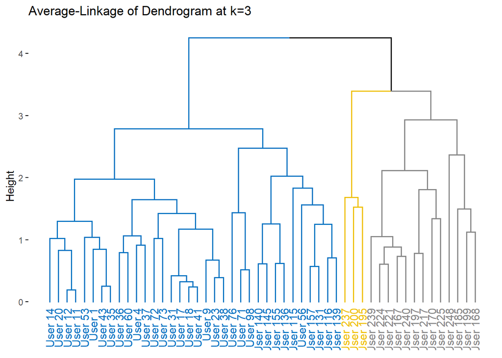

```r
#Average Linkage
avg.hclust.cut<-eclust(scaled.data,"hclust",hc_method = "average",k=3)
fviz_dend(avg.hclust.cut, show_labels=TRUE, palette="jco", as.ggplot=T, main="Average-Linkage of Dendrogram at k=3")
```

```
##   cluster size ave.sil.width
## 1       1   34          0.40
## 2       2   13          0.29
## 3       3    3          0.52
```

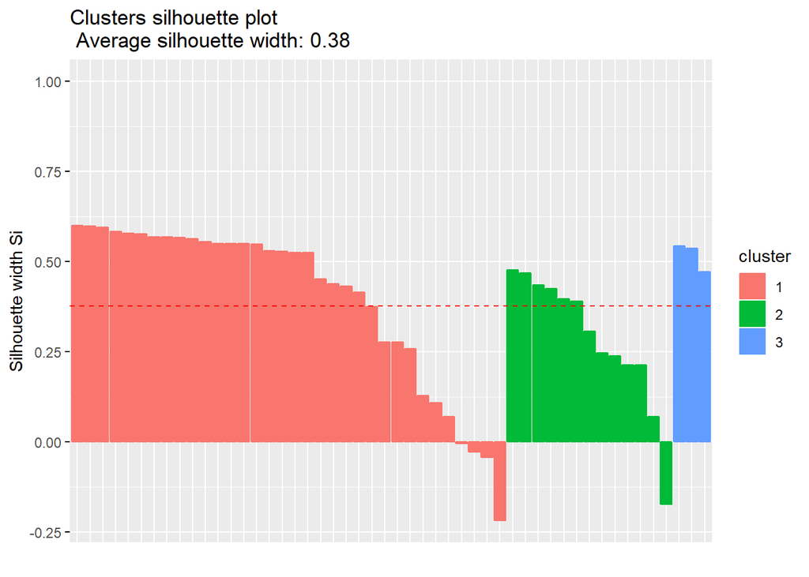

```r
fviz_silhouette(avg.hclust.cut)
```

```r
avg.sil <- summary(silhouette(cutree(avg.hclust.cut, 3), dist(scaled.data)))
cat("The silhouette index for average linkage cluster at k=3 is: ",avg.sil$avg.width,"\n")
```

```
## The silhouette index for average linkage cluster at k=3 is:  0.3775509
```

#### 2.2(f)

```r
library(NbClust)
n<-NbClust(scaled.data,method="single")
```

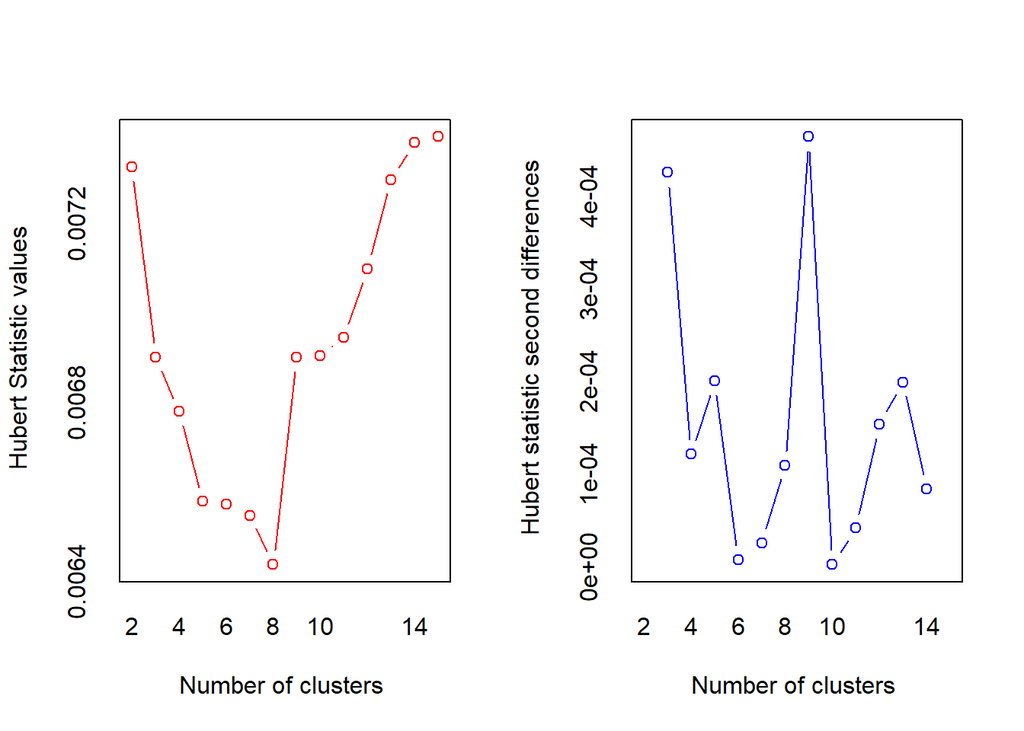

```
## *** : The Hubert index is a graphical method of determining the number of clusters.
##                 In the plot of Hubert index, we seek a significant knee that corresponds to a
##                 significant increase of the value of the measure i.e the significant peak in Hubert
##                 index second differences plot.
##
```

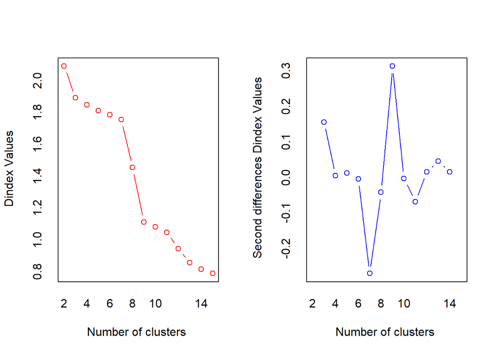

```
## *** : The D index is a graphical method of determining the number of clusters.
##                 In the plot of D index, we seek a significant knee (the significant peak in Dindex
##                 second differences plot) that corresponds to a significant increase of the value of
##                 the measure.
##
## * Among all indices:
## * 6 proposed 2 as the best number of clusters
## * 3 proposed 3 as the best number of clusters
## * 1 proposed 4 as the best number of clusters
## * 7 proposed 9 as the best number of clusters
## * 1 proposed 11 as the best number of clusters
## * 2 proposed 13 as the best number of clusters
## * 1 proposed 14 as the best number of clusters
## * 3 proposed 15 as the best number of clusters
##
##                    ***** Conclusion *****
##
## * According to the majority rule, the best number of clusters is  9
##
##
```

```r
#According to the majority rule, the best number of clusters for single linkage strategy would be : 9
```

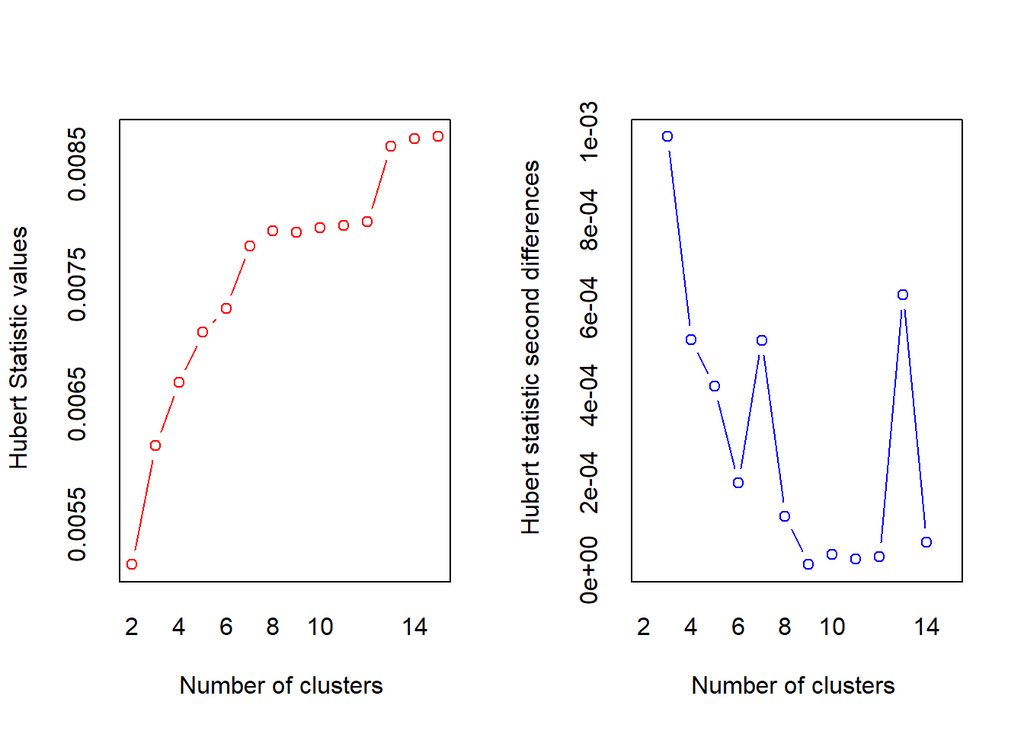

```
## *** : The Hubert index is a graphical method of determining the number of clusters.
##                 In the plot of Hubert index, we seek a significant knee that corresponds to a
##                 significant increase of the value of the measure i.e the significant peak in Hubert
##                 index second differences plot.
##
```

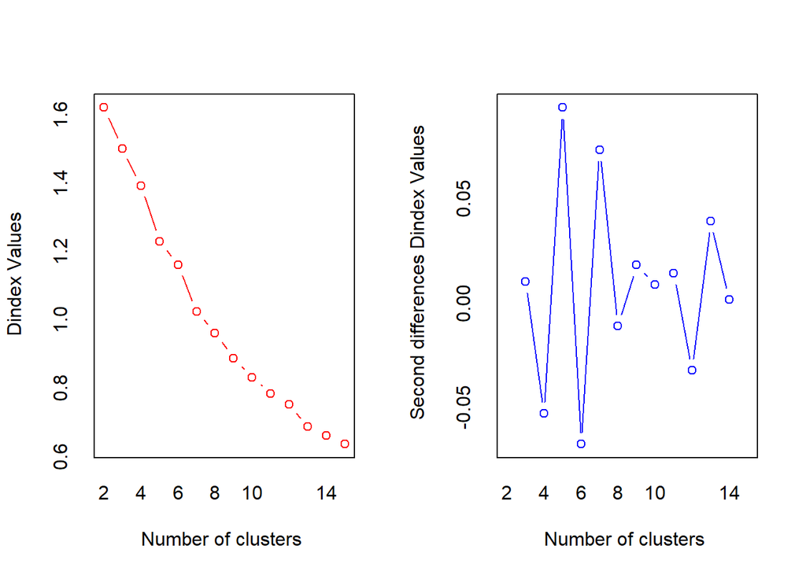

```
## *** : The D index is a graphical method of determining the number of clusters.
##                 In the plot of D index, we seek a significant knee (the significant peak in Dindex
##                 second differences plot) that corresponds to a significant increase of the value of
##                 the measure.
##
## * Among all indices:
## * 9 proposed 2 as the best number of clusters
## * 3 proposed 3 as the best number of clusters
## * 3 proposed 5 as the best number of clusters
## * 1 proposed 7 as the best number of clusters
## * 1 proposed 11 as the best number of clusters
## * 1 proposed 12 as the best number of clusters
## * 2 proposed 13 as the best number of clusters
## * 1 proposed 14 as the best number of clusters
## * 2 proposed 15 as the best number of clusters
##
##                    ***** Conclusion *****
##
## * According to the majority rule, the best number of clusters is  2
##
##
```

```
## $All.index
##         KL      CH Hartigan     CCC    Scott    Marriot    TrCovW   TraceW
## 2  14.4914 46.9075   9.1933 -0.0306  80.1498 6636265.36 1058.1850 148.6922
## 3   0.6058 31.8644   8.4750 -1.7867 108.2655 8509357.51  658.9692 124.7913
## 4   0.4633 27.3049  12.7285 -2.6062 147.8576 6853013.19  494.0157 105.7267
## 5   2.8163 28.6898   6.1854 -1.5870 191.3229 4489177.14  207.0485  82.8121
## 6   0.4082 26.7361  11.9718 -1.7656 217.0269 3866042.84  190.8952  72.8048
## 7   2.4003 29.6480   6.2310 -1.4929 266.7837 1945264.45  137.4747  57.2326
## 8   0.7864 29.2879   7.6881 -1.1590 300.4442 1295956.95   99.8483  49.9888
## 9   2.0405 30.5342   4.5339 -0.3742 333.6766  843806.23   64.7258  42.2542
## 10  1.2209 29.8992   3.8888 -0.3057 357.4652  647340.45   56.6232  38.0469
## 11  1.0673 29.1664   3.6622 -0.3375 395.9761  362590.85   48.7869  34.6757
## 12  0.4254 28.5854   7.7659 -0.3723 425.0465  241263.48   43.7133  31.6991
## 13  5.0649 31.3580   2.2639  0.6995 473.9297  106517.70   28.5004  26.3201
## 14  1.0959 30.0561   2.0633  0.3537 511.2982   58507.67   26.8222  24.8026
```

[output cut: 93 more lines]

```r
NbClust(scaled.data,method = "complete")
```

```r
#According to the majority rule, the best number of clusters for complete linkage strategy would be : 2
```

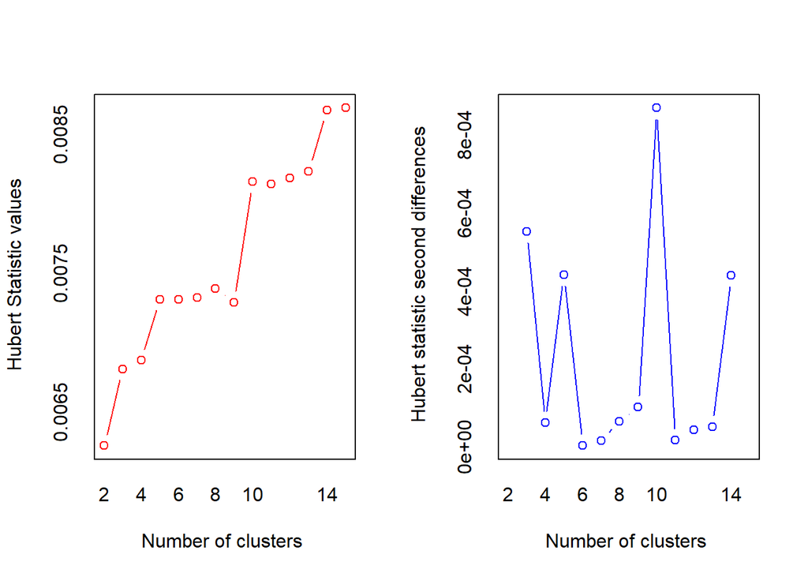

```
## *** : The Hubert index is a graphical method of determining the number of clusters.
##                 In the plot of Hubert index, we seek a significant knee that corresponds to a
##                 significant increase of the value of the measure i.e the significant peak in Hubert
##                 index second differences plot.
##
```

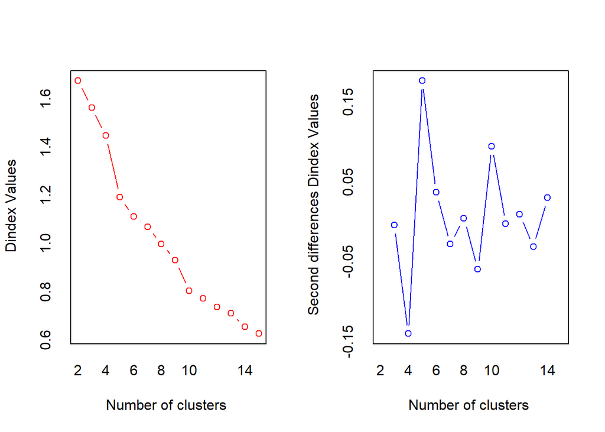

```
## *** : The D index is a graphical method of determining the number of clusters.
##                 In the plot of D index, we seek a significant knee (the significant peak in Dindex
##                 second differences plot) that corresponds to a significant increase of the value of
##                 the measure.
##
## * Among all indices:
## * 8 proposed 2 as the best number of clusters
## * 3 proposed 3 as the best number of clusters
## * 1 proposed 4 as the best number of clusters
## * 4 proposed 5 as the best number of clusters
## * 1 proposed 7 as the best number of clusters
## * 1 proposed 10 as the best number of clusters
## * 1 proposed 13 as the best number of clusters
## * 2 proposed 14 as the best number of clusters
## * 2 proposed 15 as the best number of clusters
##
##                    ***** Conclusion *****
##
## * According to the majority rule, the best number of clusters is  2
##
##
```

```
## $All.index
##         KL      CH Hartigan     CCC    Scott    Marriot    TrCovW   TraceW
## 2  42.7536 43.6317   7.6164 -0.4374  85.6793 5941492.96 1062.7221 154.0078
## 3   0.3419 28.4798   6.6439 -2.5570 109.3701 8323428.09  632.8272 132.9170
## 4   0.1333 23.3769  22.5870 -3.8772 144.9029 7270186.32  451.9154 116.4551
## 5   4.9560 31.0973   6.8376 -0.8754 223.4252 2362270.56  376.5825  78.1042
## 6   9.1609 29.3582   2.7488 -0.9457 247.4681 2103089.68  266.2071  67.8019
## 7   0.1251 25.8505   5.5486 -2.8580 277.7597 1561859.04  241.2669  63.8152
## 8   0.8923 25.2092   5.9773 -2.6594 301.7204 1263299.18  174.9706  56.5218
## 9   0.4078 25.3267  14.9595 -2.2616 333.6827  843704.50  137.2253  49.4800
## 10  9.9168 31.5989   2.6581  0.2614 385.6633  368304.77   55.8571  36.2526
## 11  0.5897 29.8298   3.5354 -0.1079 402.1022  320779.20   45.6249  33.9937
## 12  2.5897 29.1311   1.9449 -0.1797 429.3941  221171.41   38.7454  31.1682
## 13  0.1525 27.4893   7.8387 -0.6423 465.5747  125890.23   35.7438  29.6507
## 14  4.0987 30.5062   2.5521  0.5054 499.8400   73576.17   18.9938  24.4671
```

[output cut: 93 more lines]

```r
NbClust(scaled.data,method = "average")
```

```r
#According to the majority rule, the best number of clusters for average linkage strategy would be : 2
```

#### 2.2(g)

```r
single.link.sil <- summary(silhouette(cutree(single.hclust.cut, 9), dist(scaled.data)))
cat("The silhouette index for single linkage cluster at k=9 is: ",single.link.sil$avg.width,"\n")
```

```
## The silhouette index for single linkage cluster at k=9 is:  0.2254138
```

```r
complete.link.sil <- summary(silhouette(cutree(complete.hclust.cut, k = 2), dist(scaled.data)))
cat("The silhouette index for complete linkage cluster at k=2 is: ",complete.link.sil$avg.width,"\n")
```

```
## The silhouette index for complete linkage cluster at k=2 is:  0.3992433
```

```r
avg.link.sil <- summary(silhouette(cutree(avg.hclust.cut, k = 2), dist(scaled.data)))
cat("The silhouette index for average linkage cluster at k=2 is: ",avg.link.sil$avg.width,"\n")
```

```
## The silhouette index for average linkage cluster at k=2 is:  0.4173052
```

## Section 2.3

### 2.3

```r
#rm(list=ls())
htru <- read.csv("HTRU_2-small.csv", sep=",", header=T)
htru.scaled<-scale(htru[,1:8])
```

#### 2.3(a)

```r
pca <- prcomp(htru.scaled)
pca
```

```
## Standard deviations (1, .., p=8):
## [1] 2.0390930 1.4580613 0.8975401 0.6742584 0.5111361 0.3984421 0.1434342
## [8] 0.1239556
##
## Rotation (n x k) = (8 x 8):
##                        PC1        PC2         PC3         PC4          PC5
## mean             0.3621185 -0.3557532 -0.01903077 -0.28110182  0.751127908
## std.dev          0.2113048 -0.4360516  0.42887573  0.75850013  0.011659622
## kurtosis        -0.4152927  0.3181695  0.09423843  0.30579508  0.142778760
## skewness        -0.3982761  0.3111845  0.08440847  0.18828876  0.638696703
## mean.dm.snr     -0.3410716 -0.2537362  0.57746591 -0.34179528 -0.065190989
## std.dev.dm.snr  -0.3883051 -0.3139829  0.22917201 -0.24818696 -0.053784780
## kurtosis.dm.snr  0.3720056  0.4072348  0.27735030 -0.03326659  0.000972254
## skewness.dm.snr  0.2960231  0.3955042  0.58033429 -0.19279159 -0.014424030
##                         PC6          PC7          PC8
## mean            -0.02210498 -0.313434107  0.002602825
## std.dev         -0.04150390  0.063675726  0.006273999
## kurtosis        -0.04444483 -0.775594182  0.001057761
## skewness         0.02799052  0.541395908  0.011682875
## mean.dm.snr      0.59623381 -0.032101651  0.090675620
## std.dev.dm.snr  -0.75929114  0.043036463  0.235051714
## kurtosis.dm.snr -0.02144172 -0.009069735  0.785620005
## skewness.dm.snr -0.25010489  0.009147940 -0.564930160
```

```r
summary(pca)
```

```
## Importance of components:
##                           PC1    PC2    PC3     PC4     PC5     PC6
## Standard deviation     2.0391 1.4581 0.8975 0.67426 0.51114 0.39844
## Proportion of Variance 0.5197 0.2657 0.1007 0.05683 0.03266 0.01984
## Cumulative Proportion  0.5197 0.7855 0.8862 0.94301 0.97566 0.99551
##                            PC7     PC8
## Standard deviation     0.14343 0.12396
## Proportion of Variance 0.00257 0.00192
## Cumulative Proportion  0.99808 1.00000
```

##### 2.3(a)(i)

```r
cat(" The cumulative variance is explained by the first two components is : ",summary(pca)$importance['Cumulative Proportion','PC2'])
```

```
##  The cumulative variance is explained by the first two components is :  0.78548
```

##### 2.3(a)(ii)

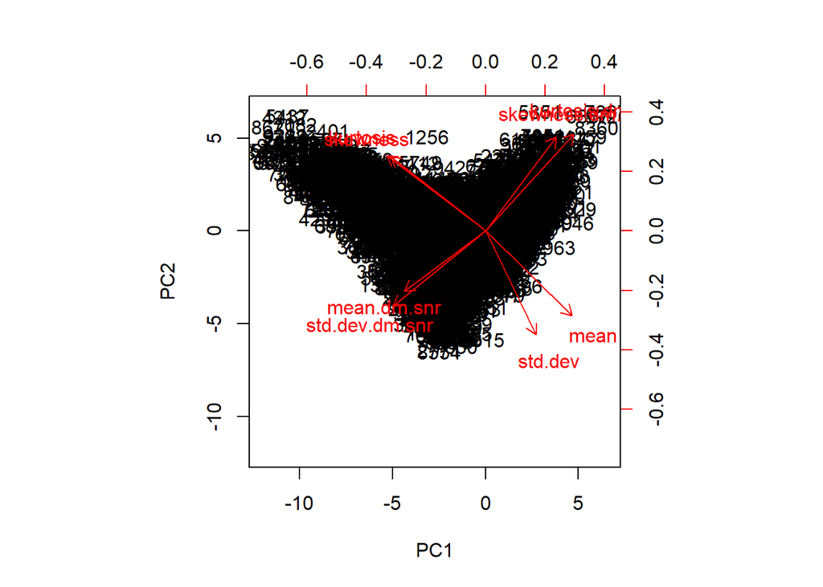

```r
library(ggfortify)
biplot(pca,scale = 0)
```

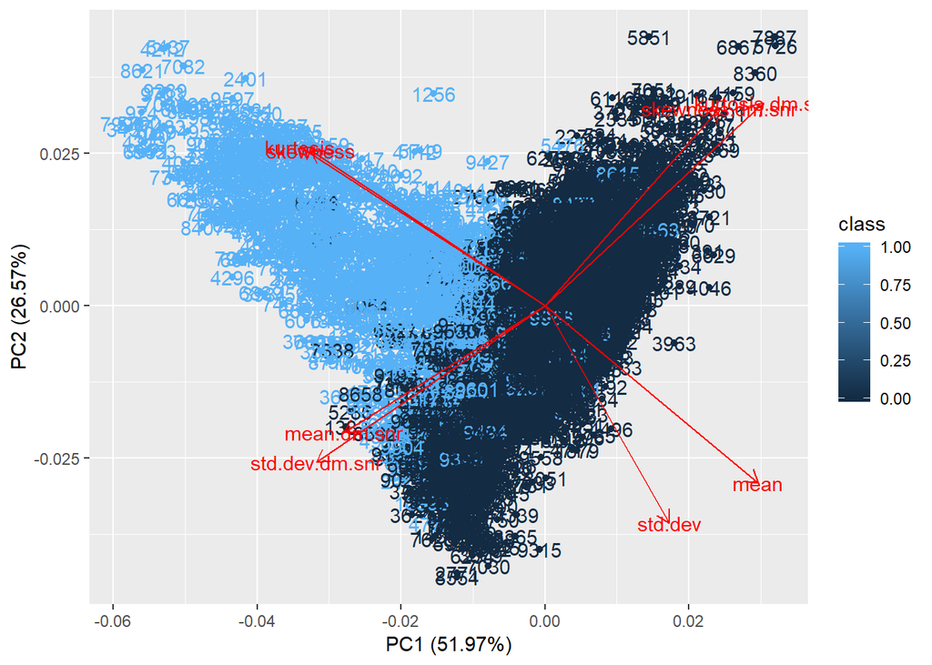

```r
#autoplot(prcomp(htru.scaled),data=htru.scaled,colours=c('red','blue'))
#autoplot(pca, data = htru, colour = 'class', loadings = TRUE)
#plot(pca$x[,1:2],colours(distinct = FALSE), pch =19, xlab ="PC1", ylab="PC2")
#ggplot(data = htru, mapping = aes(x = pca$x[,1], y = pca$x[,2], color = "class")) +
#geom_point() + labs(x="PC1",y="PC2",color= c("red","blue"))
autoplot(pca, data = htru, colour = 'class', loadings = TRUE, loadedNamespaces=TRUE, label=TRUE,loadings.label=TRUE)
```

#### 2.3(b)(i)

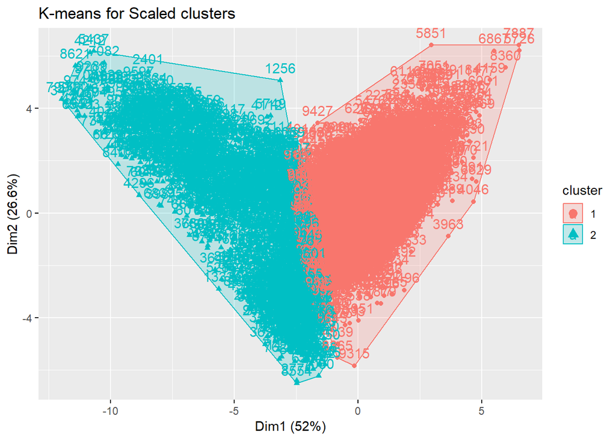

```r
pca.kmeans <- kmeans(htru.scaled, centers=2, nstart = 25)
fviz_cluster(pca.kmeans, data=htru.scaled, main="K-means for Scaled clusters")
```

#### 2.3(b)(ii) The two clusters have a similar shape. K-means takes all factors into account and PCA takes only the 2 most important variables that explains highest standard deviation.It is true that K-means clustering and PCA appear to have very different goals. Yet they are connected. If we run K means on dataset having only 2 principal component then the shape will be similar. As first two principal components always provide much information , and in our case , it explains about 78.55 %.

#### 2.3(b)(iii)

```r
cat("The distribution of observations in each cluster is as follows:\n")
```

```
## The distribution of observations in each cluster is as follows:
```

```r
cat("Cluster-1: ",pca.kmeans$size[1],"\n")
```

```
## Cluster-1:  8847
```

```r
cat("Cluster-2: ",pca.kmeans$size[2], "\n")
```

```
## Cluster-2:  1153
```

#### 2.3(b)(iv)

```r
htru.class0<-which(htru$class=="0")
htru.class1<-which(htru$class=="1")
cat("The distribution in class 0:",NROW(htru.class0),"\n")
```

```
## The distribution in class 0: 9041
```

```r
cat("The distribution in class 1:",NROW(htru.class1),"\n")
```

```
## The distribution in class 1: 959
```

```r
#cat("The distribution of classesin the HTRU dataset is ",table(htru$class))
```

#### 2.3(b)(v)

Based on the above observation, Cluster-1 corresponds to majority class and Cluster-2 corresponds to minority class.

#### 2.3(b)(vi)

```r
clstr<- pca.kmeans$cluster
cluster1 <- htru[clstr == 1,]
cluster1
```

|  | mean | std.dev | kurtosis | skewness | mean.dm.snr | std.dev.dm.snr | kurtosis.dm.snr | skewness.dm.snr | class |
| --- | --- | --- | --- | --- | --- | --- | --- | --- | --- |
| 2 | 121.75781 | 44.74943 | 0.231819049 | 0.184608611 | 3.7608696 | 22.869332 | 6.7185751 | 4.795257e+01 | 0 |
| 4 | 130.07031 | 51.38719 | -0.160128253 | -0.209469363 | 2.0250836 | 13.170139 | 10.0161090 | 1.383288e+02 | 0 |
| 5 | 111.11719 | 35.63500 | 0.237672636 | 1.679230693 | 3.6881271 | 18.683392 | 6.6633568 | 5.409050e+01 | 0 |
| 6 | 138.46094 | 52.77457 | -0.009090614 | -0.551845274 | 2.2207358 | 13.204265 | 9.9536921 | 1.394669e+02 | 0 |
| 7 | 135.73438 | 48.49637 | -0.017888840 | -0.115854459 | 3.3369565 | 20.430877 | 9.0556666 | 9.327801e+01 | 0 |
| 8 | 137.25000 | 48.86605 | -0.165120030 | -0.092291138 | 3.8520067 | 19.552793 | 6.5997513 | 5.203420e+01 | 0 |
| 9 | 102.52344 | 39.81284 | 0.079568393 | 0.898443521 | 1.5418060 | 13.950309 | 10.7893655 | 1.375421e+02 | 0 |
| 10 | 115.64844 | 52.80412 | 0.229191755 | -0.230258110 | 1.6663880 | 12.619459 | 11.4509149 | 1.706596e+02 | 0 |
| 11 | 119.72656 | 49.41560 | 0.018773177 | -0.012041510 | 2.3862876 | 15.116978 | 9.3588211 | 1.101103e+02 | 0 |
| 12 | 128.88281 | 48.80360 | 0.188491664 | 0.031535814 | 4.2608696 | 26.404029 | 6.9674676 | 5.025393e+01 | 0 |

[output cut: 8837 more lines]

```r
table(cluster1$class)
```

```
##
##    0    1
## 8624  223
```

```r
cat("The observations belonging to class 0 is : ", NROW(which(cluster1$class=="0")),"\n")
```

```
## The observations belonging to class 0 is :  8624
```

```r
cat("The observations belonging to class 1 is : ", NROW(which(cluster1$class=="1")),"\n")
```

```
## The observations belonging to class 1 is :  223
```

#### 2.3(b)(vii)

```r
cat("Based on the analysis above,class 0 with ",NROW(which(cluster1$class=="0"))," observations is represented by the larger cluster")
```

```
## Based on the analysis above,class 0 with  8624  observations is represented by the larger cluster
```

#### 2.3(b)(viii)

```r
variance<-(pca.kmeans$betweenss/pca.kmeans$totss)*100
cat("The variance explained by the clustering is :", variance,"%\n")
```

```
## The variance explained by the clustering is : 35.86788 %
```

```r
cat("Based on the observations done from the pca.kmeans, the variance is: 35.9% \n\n\n\n")
```

```
## Based on the observations done from the pca.kmeans, the variance is: 35.9%
```

```r
pca.kmeans
```

[output not shown]

[output cut: 301 more lines]

#### 2.3(b)(ix)

```r
silh<- silhouette(pca.kmeans$cluster, dist(htru.scaled))
avg.silh.width <- mean(silh[, 3])
cat("The average silhouette width of both the clusters is given by: ",avg.silh.width,"\n")
```

```
## The average silhouette width of both the clusters is given by:  0.6006794
```

```r
summary((silh))
```

```
## Silhouette of 10000 units in 2 clusters from silhouette.default(x = pca.kmeans$cluster, dist = dist(htru.scaled)) :
##  Cluster sizes and average silhouette widths:
##      8847      1153
## 0.6592013 0.1516389
## Individual silhouette widths:
##    Min. 1st Qu.  Median    Mean 3rd Qu.    Max.
## -0.2825  0.5793  0.6792  0.6007  0.7218  0.7607
```

#### 2.3(b)(x)

```r
cat("The silhouette width of Cluster 1(8847 observations) is : 0.6592013 and Cluster 2(1153 observations) is : 0.1516389  \n")
```

```
## The silhouette width of Cluster 1(8847 observations) is : 0.6592013 and Cluster 2(1153 observations) is : 0.1516389
```

```r
cat("Cluster 1 is good since its per cluster silhouette width  is close to 1.\n")
```

```
## Cluster 1 is good since its per cluster silhouette width  is close to 1.
```

#### 2.3(c)(i)

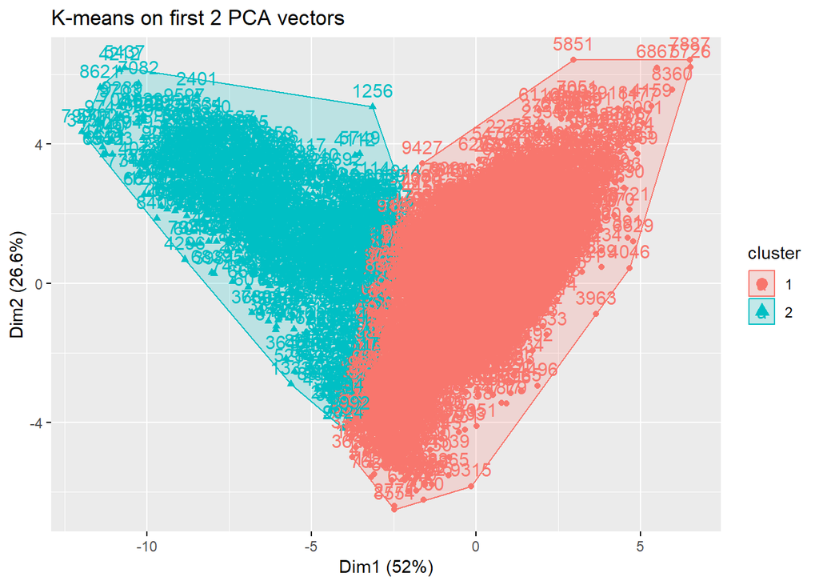

```r
pca.kmeans1 <- kmeans(pca$x[, 1:2], centers=2,nstart = 25)
fviz_cluster(pca.kmeans1, data=htru.scaled, main="K-means on first 2 PCA vectors")
```

The Shapes of all 3 plots from a(ii), b(i) and c(i) are similar. From the observation, we can say that the plot of c(i) has more observations for cluster 1 than the other 2 plots. The points in cluster 2 are more towards the negative of the Dim1.

#### 2.3(c)(ii)

```r
#library(fpc)
#pca.new <- cluster.stats(dist(pca$x[,1:2]),pca.kmeans1$cluster)
#cat("The average silhouette width of both the clusters is : ",pca.new$avg.silwidth,"\n")
```

```r
sil1<-summary(silhouette(pca.kmeans1$cluster,dist(htru.scaled)))
cat("The average silhouette width of both the clusters is : ",sil1$avg.width)
```

```
## The average silhouette width of both the clusters is :  0.6267724
```

#### 2.3(c)(iii)

```r
cat("The silhouette width of cluster 1 is : ",sil1$clus.avg.widths[1],"\n")
```

```
## The silhouette width of cluster 1 is :  0.6469393
```

```r
cat("The silhouette width of cluster 2 is : ",sil1$clus.avg.widths[2],"\n")
```

```
## The silhouette width of cluster 2 is :  0.3604778
```

```r
cat("Based on this, Cluster 1 is good as its value is close to 1")
```

```
## Based on this, Cluster 1 is good as its value is close to 1
```

#### 2.3(c)(iv)

comparing c(ii) and b(ix) values, value for avg silhouette width, c(ii) is nearer to 1 then b(ix).

comaparing c(iii) and b(x) values for per cluster Silhouette width, for cluster 1, b(x) have silhouette width more nearer to 1 then c(iii) for cluster 2, c(iii) have silhouete width more nearer to 1 then b(x)